# App data from Google Play Store

Abstract

This document investigates what makes applications on the Google Play Store successful by using publicaly available data regarding app information. By comparing app level characteristics, it is possible to gain insight into why some apps outperform others.

## Price Range and Downloads

Below is a table that displays different price ranges for apps, together with the median and average downloads for that price range. The table is sorted by average downloads.

| Price Range | Median Downloads | Average Downloads |
| --- | --- | --- |
| 0 | 100000 | 9386441.2869 |
| 5-10 | 1000 | 180813.1596 |
| 0-5 | 1000 | 70708.0707 |
| 20-25 | 10000 | 24040.0000 |
| 10-15 | 5000 | 19598.3333 |
| 40+ | 1000 | 8884.8400 |
| 25-30 | 1000 | 6003.4444 |
| 15-20 | 1000 | 5507.5000 |
| 30-35 | 1000 | 666.6667 |
| 35-40 | 100 | 368.3333 |

It is clear from the table that cheaper apps garner more downloads. While this correlation is not perfect it does roughly hold across the different price ranges. This effect is to expected in any product, not just apps. When building an app it is important to consider the trade-off between the upfront revenue versus ad-revenue. This data shows that it is a possibility that ad-revenue could outperform upfront revenue since the difference in downloads between price ranges is so large.

Note however, these average could be blown out of proportion due to hyper-successful outliers. The counter argument to that however, is the fact that for every successful app, there is likely to be an app that gets almost no downloads.

## Categories of Apps

The graph below shows the top ten categories of apps on the Google Play Store. The bars indicate average downloads, while the line represents the average size of the apps in the category.

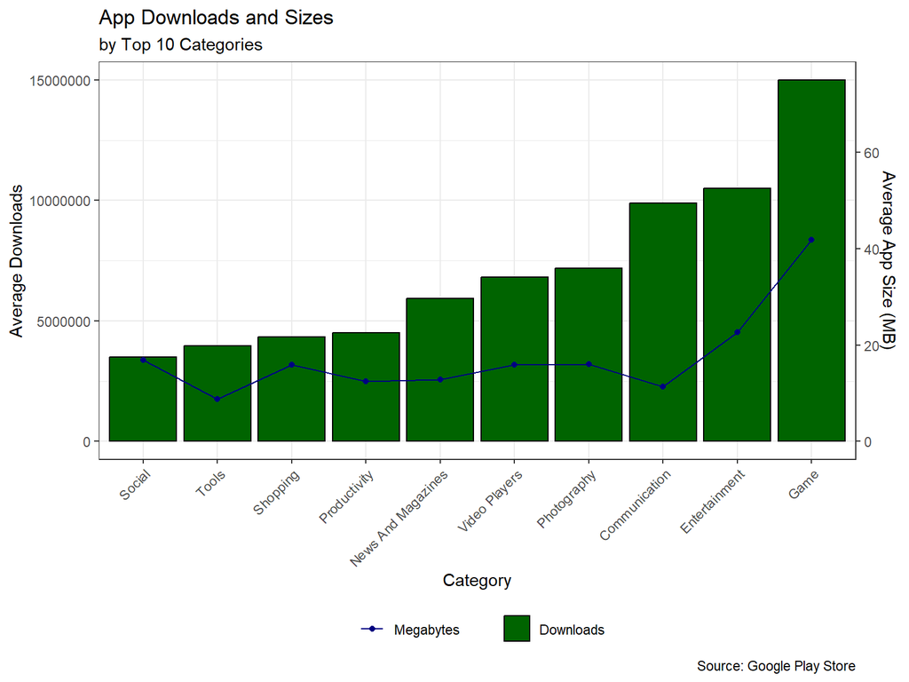

Furthermore, one should be wary of simply building a mobile app because gaming is the most popular category, since this market is likely to be saturated. Instead more market research is needed before committing to a single category of app.

-Ruan Geldenhuys